# Analysis of the Liu2015 data with DESeq2

```r
library(DESeq2)
library(ggplot2)
library(pheatmap)
```

## reading

```r
#folder  = "/shared/data/Solutions/Liu2015/041_d_STAR_map_raw/"
folder  = "041_d_STAR_map_raw/"
#folder  = "043_d_star_map_trim/"

samples = c("SRR1272187","SRR1272188","SRR1272190","SRR1272191")

# we skip the 4 first lines, which contains
# N_unmapped , N_multimapping , N_noFeature , N_ambiguous

sample_table = read.table(paste0( folder , samples[1] , "ReadsPerGene.out.tab") ,
           row.names = 1 , skip = 4 )
head( sample_table )
```

|  | V2 | V3 | V4 |
| --- | --- | --- | --- |
| ENSG00000284662 | 0 | 0 | 0 |
| ENSG00000186827 | 19 | 9 | 10 |
| ENSG00000186891 | 2 | 1 | 1 |
| ENSG00000160072 | 373 | 178 | 195 |
| ENSG00000041988 | 98 | 154 | 168 |
| ENSG00000260179 | 2 | 1 | 1 |

we are interested in the first columns, which contains counts for unstranded reads

Let’s use a loop to automatize the reading:

```r
raw_counts = data.frame( row.names =  row.names(sample_table) )


for( sample in samples ){
  sample_table = read.table(paste0( folder , sample , "ReadsPerGene.out.tab") ,
                            row.names = 1 , skip = 4 )

  raw_counts[sample] = sample_table[ row.names(raw_counts) , "V2" ]

}

head( raw_counts )
```

|  | SRR1272187 | SRR1272188 | SRR1272190 | SRR1272191 |
| --- | --- | --- | --- | --- |
| ENSG00000284662 | 0 | 0 | 0 | 0 |
| ENSG00000186827 | 19 | 29 | 30 | 126 |
| ENSG00000186891 | 2 | 0 | 2 | 1 |
| ENSG00000160072 | 373 | 338 | 244 | 307 |
| ENSG00000041988 | 98 | 114 | 85 | 122 |
| ENSG00000260179 | 2 | 4 | 1 | 1 |

## setting up the experimental design

we will also rename the raw_count table columns for clarity

- SRR1272187 : normal1
- SRR1272188 : normal2
- SRR1272190 : dilated1
- SRR1272191 : dilated2

```r
colnames(raw_counts) = c('normal1','normal2','dilated1','dilated2')
```

```r
#note: levels let's us define the reference levels
treatment <- factor( c('normal','normal','dilated','dilated') , levels = c('normal','dilated') )
colData <- data.frame(treatment, row.names = colnames(raw_counts))
colData
```

|  | treatment |
| --- | --- |
| normal1 | normal |
| normal2 | normal |
| dilated1 | dilated |
| dilated2 | dilated |

## creating the DESeq data object and some QC

```r
dds <- DESeqDataSetFromMatrix(
  countData = raw_counts, colData = colData,
  design = ~ treatment)
dim(dds)
```

```
[1] 60664     4
```

Filter low count genes.

```r
idx <- rowSums(counts(dds, normalized=FALSE) >= 10) >= 2
dds.f <- dds[idx, ]
dim(dds.f)
```

```
[1] 15161     4
```

We go from 60’664 to 15’161 genes

We perform the estimation of dispersions

```r
dds.f <- DESeq(dds.f)
```

PCA plot of the samples:

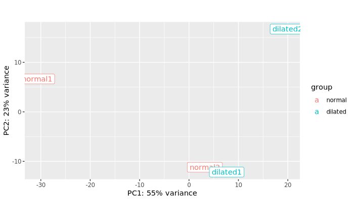

```r
# blind : whether to blind the transformation to the experimental design.
#   - blind=TRUE : comparing samples in a manner unbiased by prior information on samples,
#                  for example to perform sample QA (quality assurance).
#   - blind=FALSE: should be used for transforming data for downstream analysis,
#                  where the full use of the design information should be made.

vsd <- varianceStabilizingTransformation(dds.f, blind=TRUE )
pcaData <- plotPCA(vsd, intgroup=c("treatment"))
pcaData + geom_label(aes(x=PC1,y=PC2,label=name))
```

We plot the estimate of the dispersions

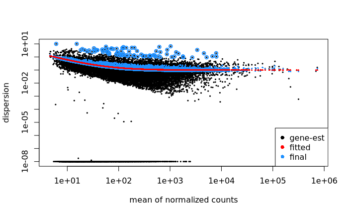

```r
# * black dot : raw
# * red dot : local trend
# * blue : corrected
plotDispEsts(dds.f)
```

There is so few genes that this does not look super nice here

```r
# extracting results for the treatment versus control contrast
res <- results(dds.f)
summary( res )
```

```
out of 15161 with nonzero total read count
adjusted p-value < 0.1
LFC > 0 (up)       : 27, 0.18%
LFC < 0 (down)     : 73, 0.48%
outliers [1]       : 0, 0%
low counts [2]     : 0, 0%
(mean count < 5)
[1] see 'cooksCutoff' argument of ?results
[2] see 'independentFiltering' argument of ?results
```

We can have a look at the coefficients of this model

```r
head(coef(dds.f)) # the second column corresponds to the difference between the 2 conditions
```

```
                Intercept treatment_dilated_vs_normal
ENSG00000186827  4.481670                   1.6229745
ENSG00000160072  8.420010                  -0.2112791
ENSG00000041988  6.648731                   0.1088040
ENSG00000225972  4.671891                   0.1389793
ENSG00000198744  6.726780                   0.4503210
ENSG00000142611  9.753430                  -0.8462170
```

Here, it contains an intercept and a coefficient for the difference between the two groups.

MA plot:

```r
res.lfc <- lfcShrink(dds.f, coef=2, res=res)
```

```
using 'apeglm' for LFC shrinkage. If used in published research, please cite:
    Zhu, A., Ibrahim, J.G., Love, M.I. (2018) Heavy-tailed prior distributions for
    sequence count data: removing the noise and preserving large differences.
    Bioinformatics. https://doi.org/10.1093/bioinformatics/bty895
```

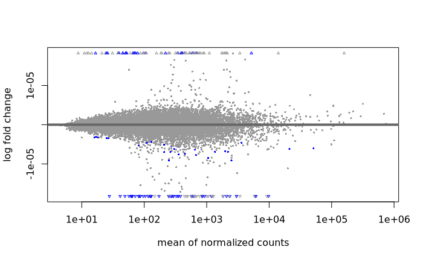

```r
DESeq2::plotMA(res.lfc)
```

Volcano plot:

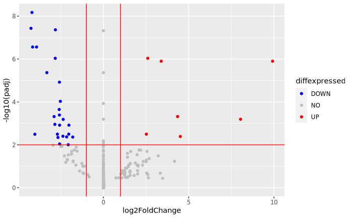

```r
FDRthreshold = 0.01
logFCthreshold = 1.0
# add a column of NAs
res.lfc$diffexpressed <- "NO"
# if log2Foldchange > 1 and pvalue < 0.01, set as "UP"
res.lfc$diffexpressed[res.lfc$log2FoldChange > logFCthreshold & res.lfc$padj < FDRthreshold] <- "UP"
# if log2Foldchange < 1 and pvalue < 0.01, set as "DOWN"
res.lfc$diffexpressed[res.lfc$log2FoldChange < -logFCthreshold & res.lfc$padj < FDRthreshold] <- "DOWN"

ggplot( data = data.frame( res.lfc ) , aes( x=log2FoldChange , y = -log10(padj) , col =diffexpressed ) ) +
  geom_point() +
  geom_vline(xintercept=c(-logFCthreshold, logFCthreshold), col="red") +
  geom_hline(yintercept=-log10(FDRthreshold), col="red") +
  scale_color_manual(values=c("blue", "grey", "red"))
```

```r
table(res.lfc$diffexpressed)
```

```
 DOWN    NO    UP
   25 15129     7
```

Heatmap:

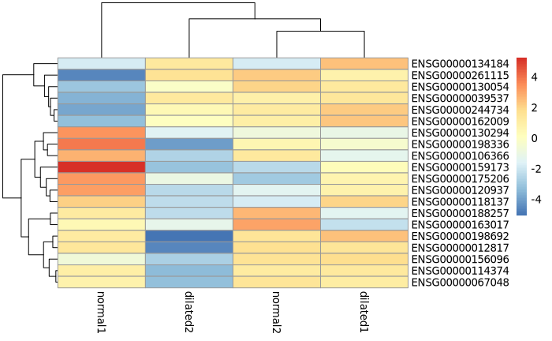

```r
vsd.counts <- assay(vsd)

topVarGenes <- head(order(rowVars(vsd.counts), decreasing = TRUE), 20)
mat  <- vsd.counts[ topVarGenes, ] #scaled counts of the top genes
mat  <- mat - rowMeans(mat)  # centering
pheatmap(mat)
```

## saving results to file

note: a CSV file can be imported into Excel

```r
write.csv( res ,'051_r_Liu2015.DESeq2.results.csv' )
```